# Distributions

## Distributions

If we flip a coin 6 times, what are the possible outcomes?

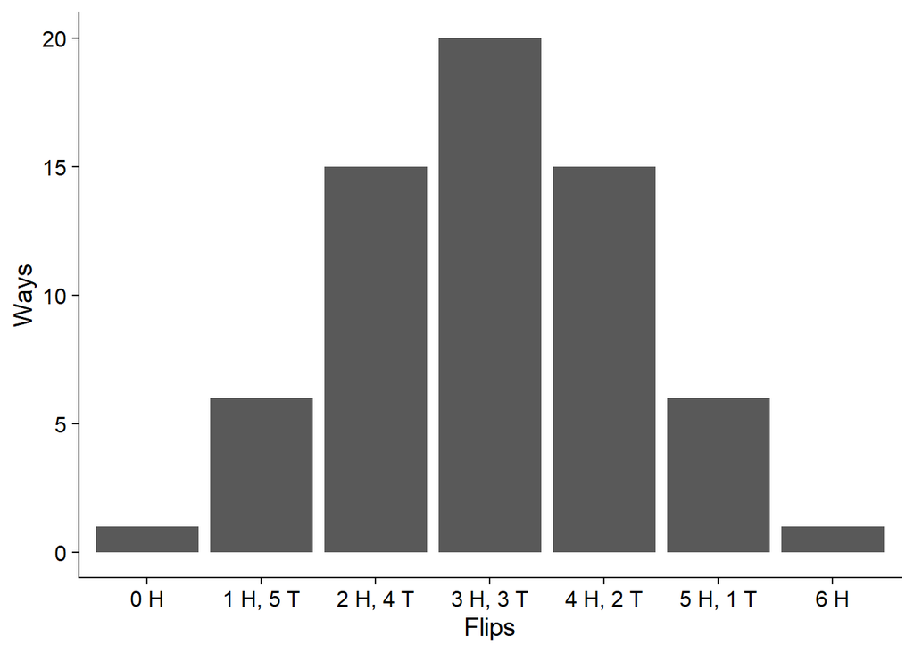

## Distributions

- All observations can be thought of as coming from a population that can be represented as a distribution
- If I flip a coin 6 times and get HHTTHT, that is one observation in a distribution of possible outcomes.
- If I catch a rodent in my swimming pool and test its endurance, that data point is one value in the larger distribution of all endurance measures for all rodents.

## Distributions most commonly encountered

1. Frequency distribution
   - Shows the number of times each measurement occurs in a sample (possibly “binned”)
2. Probability distribution:
   - A probability distribution shows the probability that measurement occurs in a sample.

## Frequency Distribution of Heads

### 6 Flips

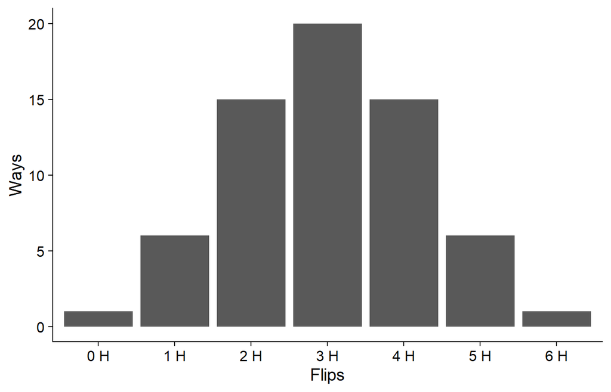

## Probability Distribution of Heads

### 6 Flips

Probability of 3 heads:

\[ Pr[3~H] = \frac{Ways~to~3~heads}{Total~\#~of~Outcomes} \]

Ways to 3 heads: 20

Total number of outcomes = 64

\[Pr[3~H] = \frac{20}{64} = 0.3125\]

## Probability Distribution of Heads

### 6 Flips

```r
flips$Ways
```

```
## [1]  1  6 15 20 15  6  1
```

```r
flips$Ways / sum(flips$Ways)
```

```
## [1] 0.015625 0.093750 0.234375 0.312500 0.234375 0.093750 0.015625
```

## Probability Distribution of Heads

### 6 Flips

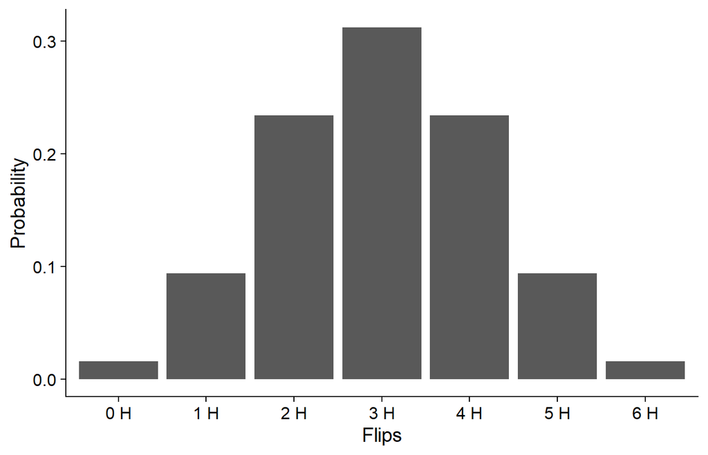

## Probability Distribution of Heads

### 6 Flips

```r
flip6$Ways / sum(flip6$Ways)
```

```
## [1] 0.015625 0.093750 0.234375 0.312500 0.234375 0.093750 0.015625
```

```r
dbinom(0:6, 6, 0.5)
```

```
## [1] 0.015625 0.093750 0.234375 0.312500 0.234375 0.093750 0.015625
```

```r
sum(dbinom(0:6, 6, 0.5))
```

```
## [1] 1
```

## Frequency distributions

```r
# Set the seed for the random number generator
set.seed(5)

# Random numbers with a mean of 0 and standard deviation of 1
M <- tibble(x = rnorm(n = 200, mean = 0, sd = 1))
```

## Frequency distributions: Continuous data

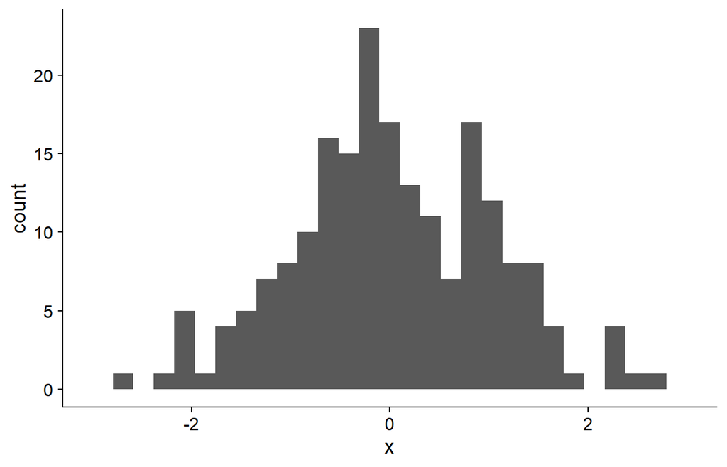

## Frequency distributions: Continuous data

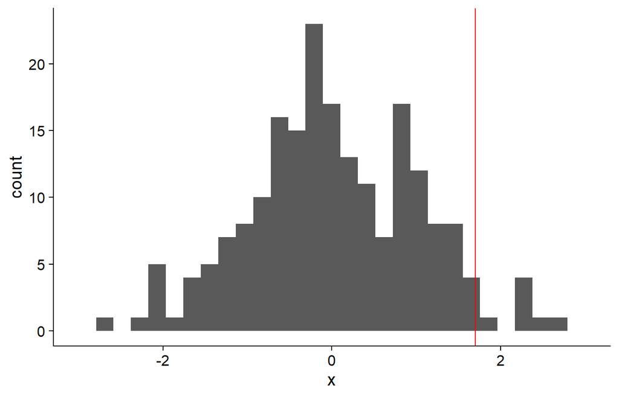

## Density plots: Visualizing probability distributions

```r
ggplot(M, aes(x = x)) +
  geom_density() +
  xlim(c(-3, 3))
```

Note `geom_density()` here instead of `geom_histogram()`. ggplot makes it easy to switch between different kinds of visualizations of the data.

## Density plots: Visualizing probability distributions

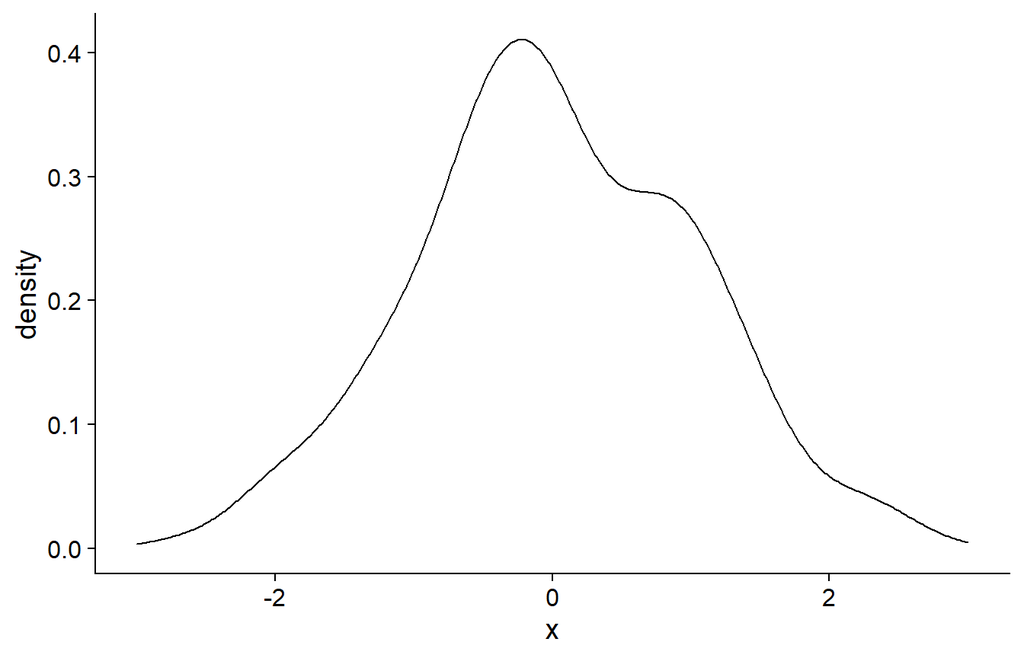

## Frequency vs. probability distribution

A frequency distribution has an underlying probability distribution.

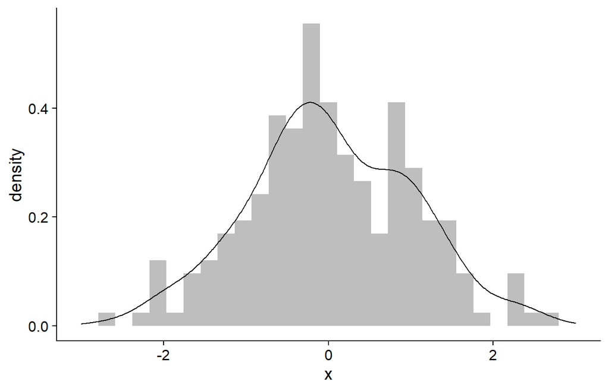

## Frequency vs. probability distribution

Generate the actual probability for \(\mu = 0\) and \(\sigma = 1\) using the normal distribution’s probability density function.

\[ f\left(Y\right)=\frac{1}{\sqrt{2\pi\sigma^{2}}}e^{\frac{-\left(Y-\mu\right)^{2}}{2\sigma^{2}}} \]

An equation is a sentence waiting to be translated.

> “There is no avoiding mathematics when doing data analysis.” (Kruschke 2015)

## Frequency vs. probability distribution

Write a function to return the probability of an observation \(Y\) for a given population mean (\(\mu\)) and standard deviation (\(\sigma\)).

\[ f\left(Y\right)=\frac{1}{\sqrt{2\pi\sigma^{2}}}e^{\frac{-\left(Y-\mu\right)^{2}}{2\sigma^{2}}} \]

```r
normal <- function(Y, mu = 0, sigma = 1){
  1 / sqrt(2 * pi * sigma ^ 2) *
    exp((-(Y - mu) ^ 2 / (2 * sigma ^ 2)))
}
```

## Frequency vs. probability distribution

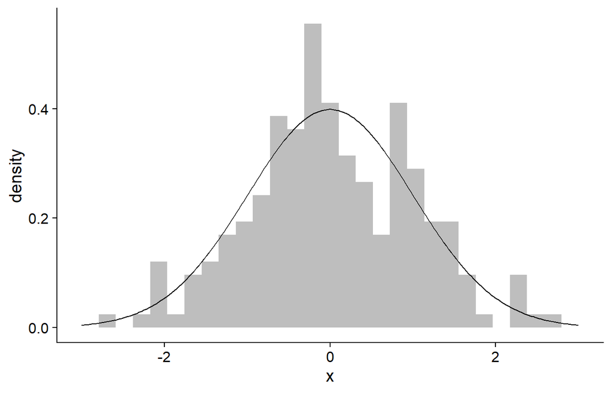

\(n = 200\) here. What about \(n = 2000\)? \(n = 200000\)?

## Probability distributions

Distribution of variables you might encounter

1. Normal (Gaussian): (continuously varying) numerical values
2. Binomial: success or failure
3. Poisson: numbers of successes per unit time or space
4. Other less often encountered probability distributions

## Normal (Gaussian)

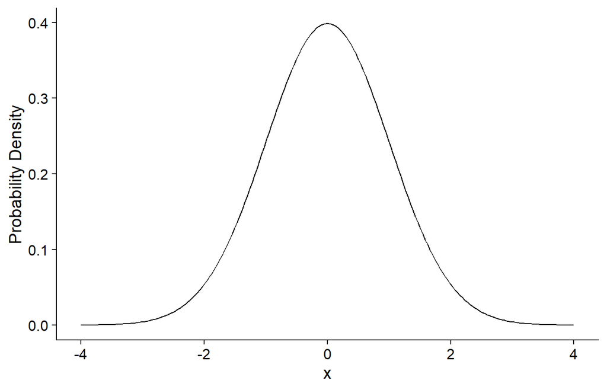

## Binomial

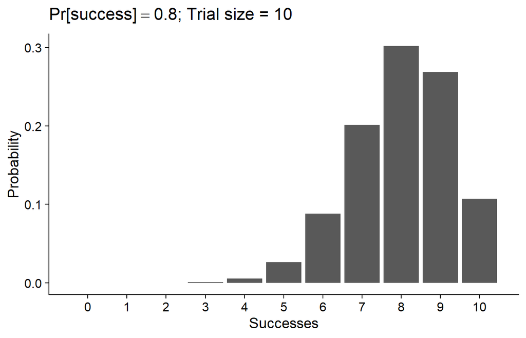

## Poisson

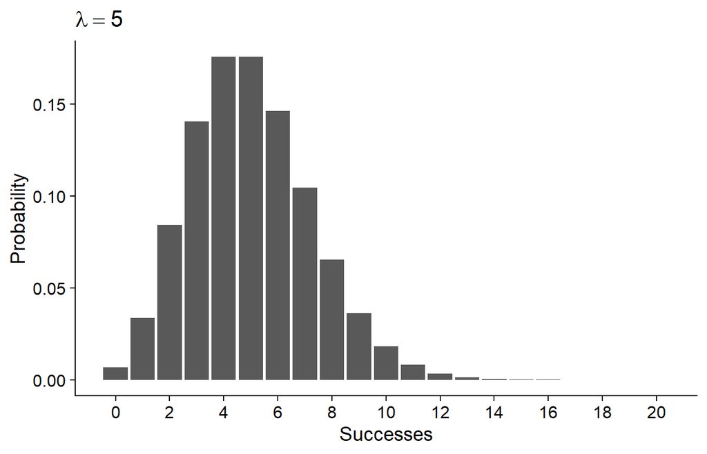

## A miscellanea of distributions

[figure not shown]

## References

Kruschke, J. K. 2015. *Doing Bayesian Data Analysis: a Tutorial with R, JAGS, and Stan*. 2nd ed. Academic Press, Boston, MA.